# NBIS Neural Nets & Deep Learning workshop

### Who we are

| Claudio | Bengt | Christophe | Dan | Per |
| --- | --- | --- | --- | --- |

| Marcin | Nikolay | Carl | Olga | Eva |
| --- | --- | --- | --- | --- |

# Who are you?

### You're our Guinea pigs!

[figure not shown]

(taken from https://www.marinij.com/2018/03/05/guinea-pigs-have-lots-of-love-and-fun-to-share/)

# Who are you?

[figure not shown]

# Who are you?

[figure not shown]

### Feedback session on Friday

We are counting on your feedback!

- Are we ready to deliver this workshop externally?
- Does the schedule work the way it's laid out?
- What did you think of the lectures and labs?
- Too simple/hard?
- Write down one thing you liked and one you didn't at the end of each session, let us know at the end

#### Online classroom

[https://nbisweden.github.io/workshop-neural-nets-and-deep-learning/classroom](https://nbisweden.github.io/workshop-neural-nets-and-deep-learning/classroom)

- Course website:  
  [https://nbisweden.github.io/workshop-neural-nets-and-deep-learning/](https://nbisweden.github.io/workshop-neural-nets-and-deep-learning/)
  - schedule with links to lectures and exercises
- The Zoom Main room for:  
  [https://uu-se.zoom.us/j/63739918797](https://uu-se.zoom.us/j/63739918797)
  - lectures
  - questions during exercises
- Zoom breakout rooms will be used for discussions in smaller groups
- Student slack channel:  
  https://nbisweden.slack.com/app_redirect?channel=nn_dl_students
  - questions during lectures or exercises
  - links to zoom and hacmd
- HackMD:  
  [https://hackmd.io/fZc9DFyDSOO5Kd4RORb4Uw](https://hackmd.io/fZc9DFyDSOO5Kd4RORb4Uw)
  - working area for exercises, etc.

# Course website

[https://nbisweden.github.io/workshop-neural-nets-and-deep-learning/](https://nbisweden.github.io/workshop-neural-nets-and-deep-learning/)

#### Online classroom

[https://nbisweden.github.io/workshop-neural-nets-and-deep-learning/classroom](https://nbisweden.github.io/workshop-neural-nets-and-deep-learning/classroom)

### Schedule

[https://nbisweden.github.io/workshop-neural-nets-and-deep-learning/schedule](https://nbisweden.github.io/workshop-neural-nets-and-deep-learning/schedule)

### Learning outcomes

[https://nbisweden.github.io/workshop-neural-nets-and-deep-learning/learningOutcomes](https://nbisweden.github.io/workshop-neural-nets-and-deep-learning/learningOutcomes)

### Prerequisites

[https://nbisweden.github.io/workshop-neural-nets-and-deep-learning/prerequisites](https://nbisweden.github.io/workshop-neural-nets-and-deep-learning/prerequisites)

### HackMD

[https://hackmd.io/fZc9DFyDSOO5Kd4RORb4Uw](https://hackmd.io/fZc9DFyDSOO5Kd4RORb4Uw?view)

#### Practical issues

- Try to keep your **cameras on**, but **microphone muted**
- Lectures with many breaks
- Take lots of small breaks also when working with the exercises
- We will try to stick to the schedule, but it's only preliminary until it's happened
- If you have any questions during the lecture, feel free to unmute and ask. If you don't want to ask in the Zoom meeting, write the question in the chat or on slack

### So, this course is about Artificial Neural networks (Anns)

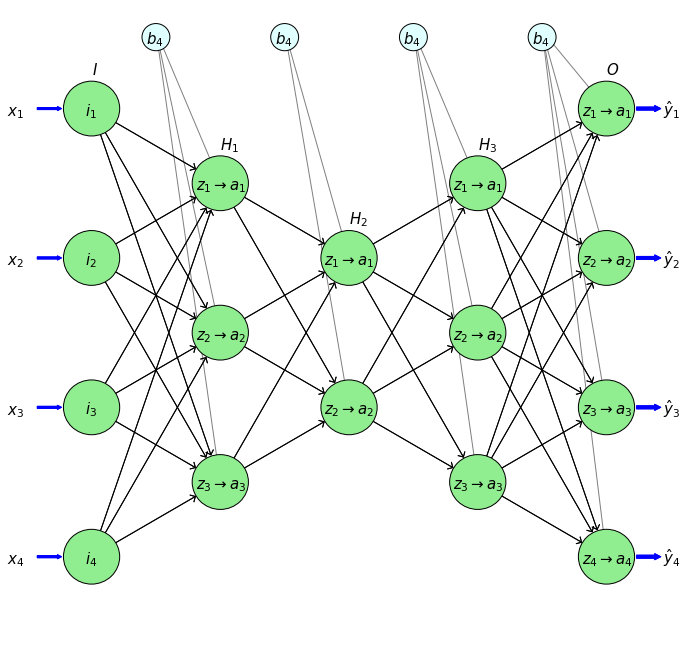

# AI vs ML vs ANN vs DL

[figure not shown]

(taken from https://medium.com/ai-in-plain-english/artificial-intelligence-vs-machine-learning-vs-deep-learning-whats-the-difference-dccce18efe7f)

#### AI -- Artificial Intelligence

- The science and engineering of creating intelligent machines
- or machines that behave as they were intelligent

#### ML -- Machine learning

- Subset of AI
- Computer algorithms that learn/improve from experience

#### ANN -- Artificial Neural Networks

- Subset of ML
- Model of human neural networks
- Networks built up by artificial neurons

#### DL -- Deep Learning

- Subset of ANN (? -- depend on definition of ANN)
- ANN with more than one hidden layer

# So where does statistics fit in?

### Statistics and ML -- parallel and overlapping?

###### Share

- methodological elements/framework
- are both data-dependent
- both have "*models*"
  - Stat: explicit probabilistic model
  - ML: implicit "*graphical*" model
    - (samples from array of models)
- problems
  - over-fitting
  - over-parameterization

###### Typically differ in

- optimization
  - Stat: analytically under the probabilistic model
  - ML: *learns* from training data, evaluates on test data
- *main* aims
  - Stat: infer relationships between variables
  - ML: predictions about unseen data
- size of data
  - stat: small vs ML: big data
    - variables and samples

# ... and what about Data Science?

[figure not shown]

(taken from https://www.javatpoint.com/data-science-vs-machine-learning)

[figure not shown]

(taken from https://crate.io/a/machine-learning-cratedb-jupyter/)

#### ... ~Don't know~ I mean, outside the scope of this study

# Where does ANN come from?

# History

### First wave of ANN (funding)

- 1943 First model of biological neruon (McCulloch & Pitts)
- 1949 Hebbian Learning rules for ANN, (Donald Hebb)
- 1951 First ANN (Minsky)
- 1958 The *Perceptron* -- linear classification
- 1969 Limitations of the perceptron (Minsky & Papert)

[figure not shown]

(taken from https://www.sciencedirect.com/topics/neuroscience/perceptron)

[figure not shown]

(taken from https://news.cornell.edu/stories/2019/09/professors-perceptron-paved-way-ai-60-years-too-soon)

# History

### Second wave of ANN (funding)

- (1975 Back propagation algorithm (Werbos))
- 1986 Back propagation rediscovered and sigmoid activation -- ANNs in vogue again
- 1985-87 ANN conferences, societies started (IEEE, INNS)
- Vanishing gradient problem
- SVM outcompetes ANNs, ANNs survives in protein structure prediction (e.g., CASP)

[figure not shown]

(taken from https://www.kdnuggets.com/2019/01/backpropagation-algorithm-demystified.html)

[figure not shown]

(taken from https://predictioncenter.org)

# History

### Third wave of ANN (funding)

- GPUs and parallelization
- "Deep Learning" buzzword and performing well in contests
- 1997 Recursive Neural Nets. LSTMs (Smidhuber & Hochreiter)
- 2000 ReLU (Hahnloser et al.?)
- 2011 CNNs
- ANNs are everywhere

[figure not shown]

(taken from https://towardsdatascience.com/a-comprehensive-guide-to-convolutional-neural-networks-the-eli5-way-3bd2b1164a53)

# Applications -- general

Written and spoke language recognition

[figure not shown]

(taken from Mouret, Jean-Baptiste & Doncieux, Stéphane. (2008). Evolutionary Intelligence

(Autoencoder) showing recogniytion of written text. ALso mention sentences more general langauge grammar and grammatics -- NLPN

Risk predictions

[figure not shown]

(taken from https://spectrum.ieee.org/computing/embedded-systems/bringing-big-neural-networks-to-selfdriving-cars-smartphones-and-drones)

Self-driving cars, risk estimation

Forecasting, weather, business

[figure not shown]

(taken from https://www.gjesm.net/article_23079.html)

Forecasting, e.g, weather

Face recognition *and* generation

[figure not shown]

(taken from https://medium.com/syncedreview/gan-2-0-nvidias-hyperrealistic-face-generator-e3439d33ebaf)

# Applications -- Biosciences

Protein structure prediction

[figure not shown]

(taken from https://www.theverge.com/2020/12/1/21754310/deepmind-alphafold-ai-protein-folding-casp-competition)

Alphafold ooutcompetes other methods in CASP 2020

Bioimaging diagnostics

[figure not shown]

(taken from https://peerj.com/articles/6201/)

Figure 3: An example of image enhancement. (A) Original malignant mass case extracted from DDSM, (B) Enhanced image using CLAHE, and (C) Histogram representation of the image.

Spatial transcriptomics

[figure not shown]

(taken from https://www.uu.se/en/news-media/press-releases/press-release/?id=5226&typ=pm&lang=en)

Decrypting spatial transcriptomics heterogeneity (spage2vec) in complex tissues

- resolution
- balance between intrinsic regul network and extrinsic subcell processes

# Time for a break

- **pattern recognition**
- non-linear classification/regression?
  - signature verification
  - cybersecurity
- image/character recognition
  - handwriting (mnist)
  - bioimages
  - faces
  - 3D object recognition
- forecasting/prediction
  - business
  - medical diagnosis
  - generate images (faces)
- dimensional reduction
  - bar-coding
- sequence recognition
  - speech
  - text
  - NLP
- data mining
- time series
- protein structure prediciton